# Career performance and Finals audiences

## Preliminary visualizations and findings

### Career production

| Player | Games | TotalPoints | PPG | RPG | APG |
| --- | --- | --- | --- | --- | --- |
| Kobe Bryant | 1346 | 33643 | 25.0 | 5.2 | 4.7 |
| LeBron James | 1627 | 43522 | 26.7 | 7.5 | 7.4 |
| Michael Jordan | 1072 | 32292 | 30.1 | 6.2 | 5.3 |

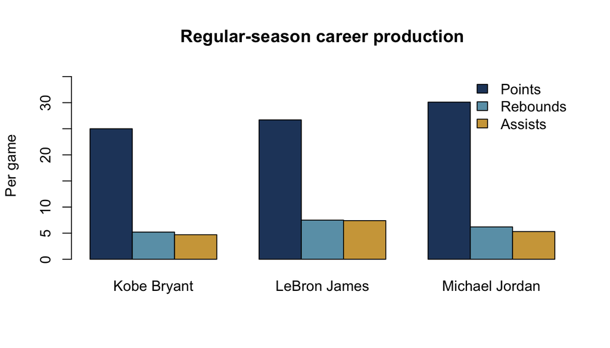

Jordan has the highest career scoring average (30.1 PPG), while LeBron has the highest rebound (7.5 RPG) and assist (7.4 APG) averages in this snapshot. Kobe averaged 25.0 PPG, 5.2 RPG and 4.7 APG. These statistics describe different contributions and do not measure defense, shot difficulty or era-adjusted value.

### Finals audiences

Series audience summaries in millions; equal weight per series

| Player | Series | Mean | Median | SD | Minimum | Maximum |
| --- | --- | --- | --- | --- | --- | --- |
| Kobe Bryant | 7 | 16.779 | 17.402 | 1.781 | 14.347 | 18.996 |
| LeBron James | 10 | 16.244 | 17.434 | 4.407 | 7.672 | 20.432 |
| Michael Jordan | 6 | 25.233 | 25.250 | 2.819 | 20.800 | 29.000 |

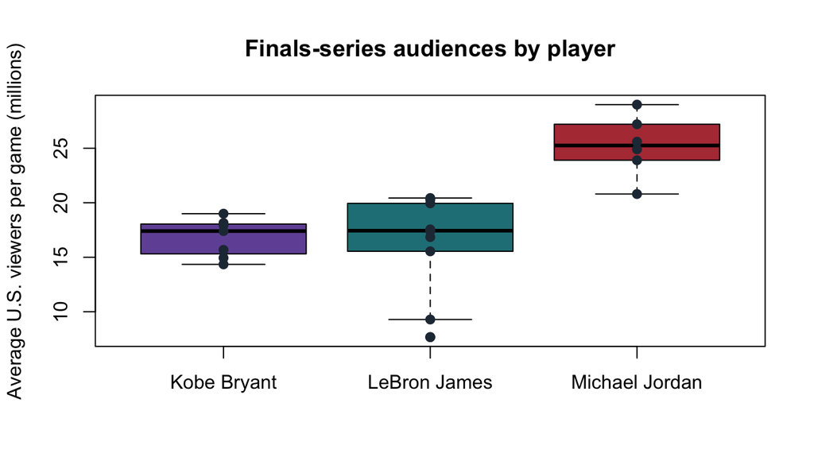

Mean series audiences are approximately 25.23 million for Jordan, 16.78 million for Kobe, and 16.24 million for LeBron. These are conditional on Finals appearances and reflect team matchups and television eras. They do not establish how many viewers each player caused to watch.

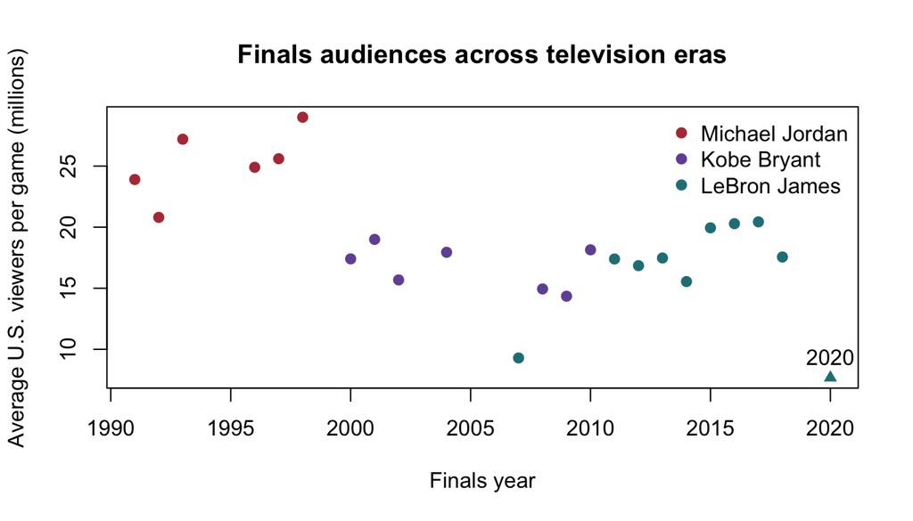

Player and era are closely connected in these records. The scatterplot helps show this limitation; audience differences cannot be assigned to player identity alone. Keep the valid 2020 bubble observation and examine its influence.

### Sensitivity to 2020

Series audience summaries excluding 2020

| Player | Series | Mean | Median | SD | Minimum | Maximum |
| --- | --- | --- | --- | --- | --- | --- |
| Kobe Bryant | 7 | 16.779 | 17.402 | 1.781 | 14.347 | 18.996 |
| LeBron James | 9 | 17.196 | 17.474 | 3.412 | 9.290 | 20.432 |
| Michael Jordan | 6 | 25.233 | 25.250 | 2.819 | 20.800 | 29.000 |

Excluding 2020 raises LeBron’s equal-series mean to about 17.20 million, compared with 16.24 million when all his appearances are included. His mean then exceeds Kobe’s 16.78 million in this dataset. Jordan’s and Kobe’s results are unchanged. This shows why the scope must be stated alongside any ranking.

### Jersey popularity: selected reporting periods

Selected published jersey rankings; lower rank means higher placement

| Player | ReportDateOrYear | SalesRank |
| --- | --- | --- |
| Michael Jordan | 2003 | 4 |
| Kobe Bryant | 2003 | 1 |
| Kobe Bryant | 2011-04-14 | 2 |
| LeBron James | 2011-04-14 | 1 |
| Kobe Bryant | 2012-04-26 | 3 |
| LeBron James | 2012-04-26 | 4 |

In the cited 2003 list, Kobe ranked first and Jordan fourth. In the NBA’s April 2011 release, LeBron ranked first and Kobe second; in April 2012, Kobe ranked third and LeBron fourth. These are selected historical snapshots with differing periods and retail scopes. They are not career sales totals. Units sold and revenue are unavailable, so the current data cannot support a three-player career jersey-sales ranking. Additional matched-period data would be needed.